🏠 Inicio del curso | 📊 Rendimiento y riesgo

# Calculos de retornos

## Descarga de la información y calculo de los retornos de los activos

Antes de empezar, debemos de cargar las librerias y metodos que necesitamos para esta sesion.

```python
# Vamos a instalar el paquete ffn que no esta instalado por defecto en colab

!pip install ffn
```

```python
import pandas as pd
import numpy as np
import yfinance as yf
import matplotlib.pyplot as plt
import matplotlib.ticker as mtick
import plotly.express as px
import plotly.io as pio
pio.renderers.default = "notebook"
import statsmodels.stats.api as sms
from scipy import stats
import ffn
```

Ahora iniciemos la descarga de la inforamción de los precios de la accion de NVIDIA (NVDA).

```python
df = yf.download(["NVDA"],
                 start = "2021-12-31",
                 #end = "2026-07-31",
                 progress = False,
                 auto_adjust = False,
                 multi_level_index = False)
```

```python
print(f"Downloaded {len(df)} rows of data.")
df
```

```
Downloaded 1152 rows of data.
```

| Date | Adj Close | Close | High | Low | Open | Volume |
| --- | --- | --- | --- | --- | --- | --- |
| 2021-12-31 | 29.318375 | 29.410999 | 30.030001 | 29.330999 | 29.674000 | 266530000 |
| 2022-01-03 | 30.026146 | 30.121000 | 30.711000 | 29.785000 | 29.815001 | 391547000 |
| 2022-01-04 | 29.197765 | 29.290001 | 30.468000 | 28.349001 | 30.277000 | 527154000 |
| 2022-01-05 | 27.517067 | 27.604000 | 29.416000 | 27.533001 | 28.948999 | 498064000 |
| 2022-01-06 | 28.089260 | 28.177999 | 28.438000 | 27.065001 | 27.639999 | 454186000 |
| ... | ... | ... | ... | ... | ... | ... |
| 2026-07-30 | 195.039993 | 195.039993 | 197.250000 | 191.520004 | 193.449997 | 129010200 |
| 2026-07-31 | 200.750000 | 200.750000 | 202.000000 | 194.949997 | 198.440002 | 139961200 |
| 2026-08-03 | 206.639999 | 206.639999 | 208.740005 | 196.850006 | 197.690002 | 128406900 |
| 2026-08-04 | 211.940002 | 211.940002 | 213.059998 | 209.050003 | 211.300003 | 134922000 |
| 2026-08-05 | 219.220001 | 219.220001 | 222.220001 | 216.399994 | 216.860001 | 156378175 |

1152 rows × 6 columns

Solo necesitamos el precio de cierre ajustado, procedamos a eliminar las demas variables.

```python
df_dia = df.loc[:, ["Adj Close"]]
df_dia
```

| Date | Adj Close |
| --- | --- |
| 2021-12-31 | 29.318375 |
| 2022-01-03 | 30.026146 |
| 2022-01-04 | 29.197765 |
| 2022-01-05 | 27.517067 |
| 2022-01-06 | 28.089260 |
| ... | ... |
| 2026-07-30 | 195.039993 |
| 2026-07-31 | 200.750000 |
| 2026-08-03 | 206.639999 |
| 2026-08-04 | 211.940002 |
| 2026-08-05 | 219.220001 |

1152 rows × 1 columns

Ahora calculemos los dos tipos de retornos.

```python
df_rtn = df_dia.copy()
df_rtn["simple_rtn"] = df_rtn["Adj Close"].pct_change() # Retornos discretos
df_rtn["log_rtn"] = np.log(df_rtn["Adj Close"]/df_rtn["Adj Close"].shift(1)) # Retornos continuos
df_rtn.dropna(inplace=True)
df_rtn.head()
```

| Date | Adj Close | simple_rtn | log_rtn |
| --- | --- | --- | --- |
| 2022-01-03 | 30.026146 | 0.024141 | 0.023854 |
| 2022-01-04 | 29.197765 | -0.027589 | -0.027976 |
| 2022-01-05 | 27.517067 | -0.057563 | -0.059286 |
| 2022-01-06 | 28.089260 | 0.020794 | 0.020581 |
| 2022-01-07 | 27.161188 | -0.033040 | -0.033598 |

Veamos una forma de hacerlo mas fácil. Usando la librería `ffn`

```python
df_rtn_2 = df_dia.copy()
df_rtn_2["simple_rtn"] = df_rtn_2["Adj Close"].to_returns() # Retornos discretos, requiere libreria ffn
df_rtn_2["log_rtn"] = df_rtn_2["Adj Close"].to_log_returns() # Retornos continuos, requiere libreria ffn
df_rtn_2.dropna(inplace=True)
df_rtn_2.head()
```

| Date | Adj Close | simple_rtn | log_rtn |
| --- | --- | --- | --- |
| 2022-01-03 | 30.026146 | 0.024141 | 0.023854 |
| 2022-01-04 | 29.197765 | -0.027589 | -0.027976 |
| 2022-01-05 | 27.517067 | -0.057563 | -0.059286 |
| 2022-01-06 | 28.089260 | 0.020794 | 0.020581 |
| 2022-01-07 | 27.161188 | -0.033040 | -0.033598 |

### Cambiando la frecuencia de los retornos

Que sucede si necesitamos los retornos semanales o mensuales, en vez de los diarios.

```python
df_semana = df_dia.resample(rule="W").ffill()
df_semana["simple_rtn"] = df_semana["Adj Close"].to_returns()
df_semana["log_rtn"] = df_semana["Adj Close"].to_log_returns()
df_semana.dropna(inplace=True)
df_semana.head()
```

| Date | Adj Close | simple_rtn | log_rtn |
| --- | --- | --- | --- |
| 2022-01-09 | 27.161188 | -0.073578 | -0.076425 |
| 2022-01-16 | 26.857157 | -0.011194 | -0.011257 |
| 2022-01-23 | 23.300394 | -0.132433 | -0.142062 |
| 2022-01-30 | 22.768074 | -0.022846 | -0.023111 |
| 2022-02-06 | 24.242409 | 0.064754 | 0.062744 |

```python
# Y si los queremos mensual

df_mes = df_dia.resample(rule="ME").ffill()
df_mes["simple_rtn"] = df_mes["Adj Close"].to_returns()
df_mes["log_rtn"] = df_mes["Adj Close"].to_log_returns()
df_mes.dropna(inplace=True)
df_mes.head()
```

| Date | Adj Close | simple_rtn | log_rtn |
| --- | --- | --- | --- |
| 2022-01-31 | 24.408888 | -0.167454 | -0.183267 |
| 2022-02-28 | 24.308208 | -0.004125 | -0.004133 |
| 2022-03-31 | 27.204702 | 0.119157 | 0.112576 |
| 2022-04-30 | 18.491749 | -0.320274 | -0.386065 |
| 2022-05-31 | 18.616371 | 0.006739 | 0.006717 |

## Visualizando los retornos

Una vez tenemos los retornos calculados. Vamos a ver como los podemos graficar.

Veamos como usar directamente `pandas` para hacer un grafico inicial del precio.

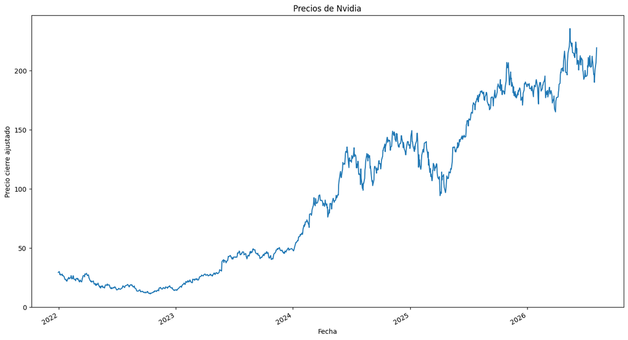

```python
df_dia["Adj Close"].plot(title="Precios de Nvidia",
                         xlabel="Fecha",
                         ylabel="Precio cierre ajustado",
                         figsize=(16,9))
plt.show()
```

Ahora hagamos lo mismo para los retornos.

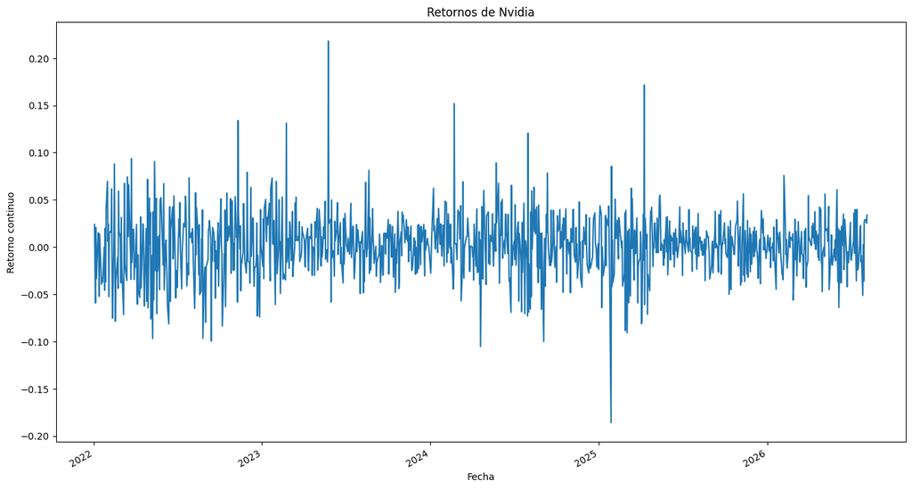

```python
df_rtn["log_rtn"].plot(title="Retornos de Nvidia",
                         xlabel="Fecha",
                         ylabel="Retorno continuo",
                         figsize=(16,9))
plt.show()
```

### Graficando los precios y los retornos juntos

Una alternativa es la de graficar los precios en conjunto con los retornos, alineando los valores del eje x. Vamos a ver como lo podemos hacer.

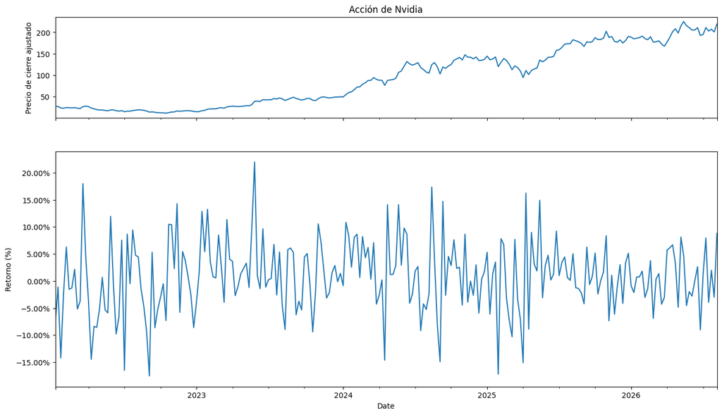

```python
fig, ax = plt.subplots(nrows=2,
                       ncols=1,
                       sharex=True,
                       figsize = (16,9),
                       height_ratios = (3,7))

df_semana["Adj Close"].plot(ax=ax[0])
ax[0].set(title = "Acción de Nvidia",
          ylabel = "Precio de cierre ajustado")

df_semana["log_rtn"].plot(ax=ax[1])
ax[1].set(ylabel = "Retorno (%)")
ax[1].yaxis.set_major_formatter(mtick.PercentFormatter(xmax=1, decimals=2))

plt.show()
```

### Gráficos interactivos

Otra posibilidad es la de crear graficos alternativos, usando la libreria `plotly`. Pero, invocando el grafico desde `pandas`. Veamos como lo podemos construir para los precios.

```python
df_semana["Adj Close"].plot(title="Precios de Nvidia",
                            backend="plotly")
```

[interactive chart not shown]

Ahora, para los retornos.

```python
df_semana["log_rtn"].plot(title="Retornos de Nvidia",
                          backend="plotly")
```

[interactive chart not shown]

Esta opcion tiene limitaciones para ajustar los parametros del grafico. Si deseamos poder ajustar mas caracterisiticas del grafico, podemos usar directamente el paquete `plotly`.

```python
fig = px.line(data_frame = df_semana,
              y = "log_rtn",
              title = "Retorno semanal de la acción de Nvidia",
              labels = {"Date":"Fecha",
                        "log_rtn":"Retorno"})
fig.update_layout(yaxis_tickformat = ".1%")
fig.show()
```

[interactive chart not shown]

## Medidas estadisticas basicas de los retornos.

Es muy facil calcular las estadisticas descriptivas basicas de un base de datos. Para los retornos continuos en nuestra base de datos de precios de NVIDIA (NVDA), se tiene:

```python
df_semana["log_rtn"].describe(percentiles = [0.05, 0.25, 0.5, 0.75, 0.95])
```

```
count    240.000000
mean       0.008383
std        0.066141
min       -0.175188
5%        -0.091663
25%       -0.031608
50%        0.007746
75%        0.050479
95%        0.113787
max        0.219709
Name: log_rtn, dtype: float64
```

Para la base de datos completa (la funcion solo se aplica a las variables cuantitativas), se tiene:

**Nota:** No se debe de calcular las estadisticas descriptivas del precio de la accion, solo para los retornos.

```python
df_semana[["simple_rtn", "log_rtn"]].describe(percentiles = [0.05, 0.25, 0.5, 0.75, 0.95])
```

|  | simple_rtn | log_rtn |
| --- | --- | --- |
| count | 240.000000 | 240.000000 |
| mean | 0.010618 | 0.008383 |
| std | 0.066969 | 0.066141 |
| min | -0.160701 | -0.175188 |
| 5% | -0.087587 | -0.091663 |
| 25% | -0.031113 | -0.031608 |
| 50% | 0.007776 | 0.007746 |
| 75% | 0.051775 | 0.050479 |
| 95% | 0.120514 | 0.113787 |
| max | 0.245714 | 0.219709 |

## Histograma de los retornos

Vamos a construir el histograma de los retornos.

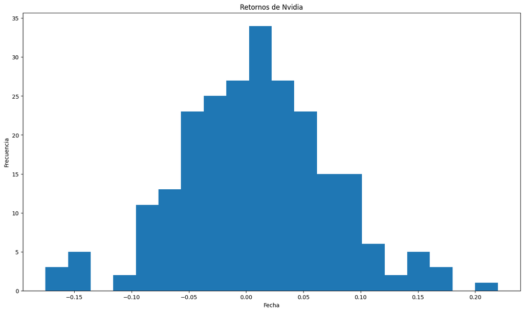

```python
df_semana["log_rtn"].plot.hist(title="Retornos de Nvidia",
                               xlabel="Fecha",
                               ylabel="Frecuencia",
                               figsize=(16,9),
                               bins=20)
plt.show()
```

Para construir los graficos dinamicos se tiene:

```python
fig = px.histogram(data_frame = df_semana,
             x="log_rtn",
             title = "Retorno semanal de la acción de Nvidia",
             labels = {"log_rtn":"Retorno"},
             nbins = 20)
fig.update_layout(xaxis_tickformat = ".1%")
fig.show()
```

[interactive chart not shown]

## Probando si los retornos siguen una distribución normal

Vamos a probar si los retornos semanales de NVIDIA (NVDA) siguen una distribucion normal.

```python
JB, p_JB, skew, kurt = sms.jarque_bera(resids = df_semana["log_rtn"])

print(f"Valor estadístico JB: {JB:.4f} con un valor p de {p_JB:.4f}")
```

```
Valor estadístico JB: 2.2822 con un valor p de 0.3195
```

## Intervalo de confianza de la media de los retornos

```python
li, ls = stats.t.interval(confidence = 0.95,
                          df = len(df_semana["log_rtn"])-1,
                          loc = np.mean(df_semana["log_rtn"]),
                          scale = stats.sem(df_semana["log_rtn"]))
print(f"Intervalo de confianza de la media de los retornos: LI: {li:.4%}, LS: {ls:.4%}")
```

```
Intervalo de confianza de la media de los retornos: LI: -0.0028%, LS: 1.6793%
```

```python
t_stat, p_value = stats.ttest_1samp(df_semana["log_rtn"], popmean=0)

print(f"Estadístico t: {t_stat:.4f}")
print(f"Valor p: {p_value:.4f}")
```

```
Estadístico t: 1.9635
Valor p: 0.0508
```

## Calculo de las medidas de relación lineal

### Descarga de retornos de diversas empresas

```python
activos = ["AAPL", "NVDA", "AMZN", "TSLA"]
df_multiple = yf.download(activos,
                 start = "2021-12-31",
                 end = "2026-07-31",
                 progress = False,
                 auto_adjust = False, # Trae ambos precios de cierre, ajustados y no ajustados
                 multi_level_index = False)
df_multiple
```

| Price Ticker Date | Adj Close AAPL | Adj Close AMZN | Adj Close NVDA | Adj Close TSLA | Close AAPL | Close AMZN | Close NVDA | Close TSLA | High AAPL | High AMZN | ... | Low NVDA | Low TSLA | Open AAPL | Open AMZN | Open NVDA | Open TSLA | Volume AAPL | Volume AMZN | Volume NVDA | Volume TSLA |
| --- | --- | --- | --- | --- | --- | --- | --- | --- | --- | --- | --- | --- | --- | --- | --- | --- | --- | --- | --- | --- | --- |
| 2021-12-31 | 173.599045 | 166.716995 | 29.318377 | 352.260010 | 177.570007 | 166.716995 | 29.410999 | 352.260010 | 179.229996 | 169.350006 | ... | 29.330999 | 351.529999 | 178.089996 | 168.955994 | 29.674000 | 357.813324 | 64062300 | 47830000 | 266530000 | 40733700 |
| 2022-01-03 | 177.939743 | 170.404495 | 30.026140 | 399.926666 | 182.009995 | 170.404495 | 30.121000 | 399.926666 | 182.880005 | 170.703506 | ... | 29.785000 | 378.679993 | 177.830002 | 167.550003 | 29.815001 | 382.583344 | 104487900 | 63520000 | 391547000 | 103931400 |
| 2022-01-04 | 175.681366 | 167.522003 | 29.197763 | 383.196655 | 179.699997 | 167.522003 | 29.290001 | 383.196655 | 182.940002 | 171.399994 | ... | 28.349001 | 374.350006 | 182.630005 | 170.438004 | 30.277000 | 396.516663 | 99310400 | 70726000 | 527154000 | 100248300 |
| 2022-01-05 | 171.008255 | 164.356995 | 27.517075 | 362.706665 | 174.919998 | 164.356995 | 27.604000 | 362.706665 | 180.169998 | 167.126495 | ... | 27.533001 | 360.336670 | 179.610001 | 166.882996 | 28.948999 | 382.216675 | 94537600 | 64302000 | 498064000 | 80119800 |
| 2022-01-06 | 168.153580 | 163.253998 | 28.089260 | 354.899994 | 172.000000 | 163.253998 | 28.177999 | 354.899994 | 175.300003 | 164.800003 | ... | 27.065001 | 340.166656 | 172.699997 | 163.450500 | 27.639999 | 359.000000 | 96904000 | 51958000 | 454186000 | 90336600 |
| ... | ... | ... | ... | ... | ... | ... | ... | ... | ... | ... | ... | ... | ... | ... | ... | ... | ... | ... | ... | ... | ... |
| 2026-07-24 | 333.019989 | 232.110001 | 206.839996 | 313.029999 | 333.019989 | 232.110001 | 206.839996 | 313.029999 | 334.369995 | 234.949997 | ... | 204.809998 | 306.510010 | 321.790009 | 234.380005 | 207.449997 | 320.720001 | 47489400 | 35017400 | 114836800 | 62760000 |
| 2026-07-27 | 336.910004 | 231.389999 | 196.509995 | 309.220001 | 336.910004 | 231.389999 | 196.509995 | 309.220001 | 339.570007 | 235.889999 | ... | 195.440002 | 304.279999 | 334.540009 | 235.669998 | 208.199997 | 313.239990 | 49604300 | 34999500 | 154353700 | 44919400 |
| 2026-07-28 | 340.079987 | 230.860001 | 197.009995 | 307.440002 | 340.079987 | 230.860001 | 197.009995 | 307.440002 | 342.890015 | 233.110001 | ... | 192.740005 | 300.690002 | 340.029999 | 232.850006 | 195.000000 | 305.929993 | 51859000 | 44521600 | 134111500 | 39802400 |
| 2026-07-29 | 338.190002 | 226.649994 | 190.009995 | 298.320007 | 338.190002 | 226.649994 | 190.009995 | 298.320007 | 344.570007 | 232.820007 | ... | 190.009995 | 297.380005 | 339.730011 | 229.320007 | 195.850006 | 307.140015 | 56090800 | 44957500 | 147680800 | 39478000 |
| 2026-07-30 | 333.429993 | 235.500000 | 195.039993 | 308.850006 | 333.429993 | 235.500000 | 195.039993 | 308.850006 | 334.750000 | 239.820007 | ... | 191.520004 | 301.329987 | 333.100006 | 233.350006 | 193.449997 | 302.700012 | 74817800 | 101839800 | 129010200 | 38005400 |

1148 rows × 24 columns

```python
df_multiple = df_multiple.loc[:,["Adj Close"]] # Seleccionamos solo los precios de cierre ajustados
df_multiple.columns = df_multiple.columns.droplevel() # Eliminamos encabezados de columna innecesarios
df_multiple = df_multiple[activos] # Reordenamos las acciones en el orden que deseamos hacer la consulta
df_multiple
```

| Ticker Date | AAPL | NVDA | AMZN | TSLA |
| --- | --- | --- | --- | --- |
| 2021-12-31 | 173.599045 | 29.318377 | 166.716995 | 352.260010 |
| 2022-01-03 | 177.939743 | 30.026140 | 170.404495 | 399.926666 |
| 2022-01-04 | 175.681366 | 29.197763 | 167.522003 | 383.196655 |
| 2022-01-05 | 171.008255 | 27.517075 | 164.356995 | 362.706665 |
| 2022-01-06 | 168.153580 | 28.089260 | 163.253998 | 354.899994 |
| ... | ... | ... | ... | ... |
| 2026-07-24 | 333.019989 | 206.839996 | 232.110001 | 313.029999 |
| 2026-07-27 | 336.910004 | 196.509995 | 231.389999 | 309.220001 |
| 2026-07-28 | 340.079987 | 197.009995 | 230.860001 | 307.440002 |
| 2026-07-29 | 338.190002 | 190.009995 | 226.649994 | 298.320007 |
| 2026-07-30 | 333.429993 | 195.039993 | 235.500000 | 308.850006 |

1148 rows × 4 columns

```python
df_multiple_returns = df_multiple.copy()
df_multiple_returns["AAPL"] = np.log(df_multiple_returns["AAPL"]/df_multiple_returns["AAPL"].shift(1))
df_multiple_returns["AMZN"] = np.log(df_multiple_returns["AMZN"]/df_multiple_returns["AMZN"].shift(1))
df_multiple_returns["NVDA"] = np.log(df_multiple_returns["NVDA"]/df_multiple_returns["NVDA"].shift(1))
df_multiple_returns["TSLA"] = np.log(df_multiple_returns["TSLA"]/df_multiple_returns["TSLA"].shift(1))
df_multiple_returns.dropna(inplace=True)
df_multiple_returns
```

| Ticker Date | AAPL | NVDA | AMZN | TSLA |
| --- | --- | --- | --- | --- |
| 2022-01-03 | 0.024697 | 0.023854 | 0.021877 | 0.126912 |
| 2022-01-04 | -0.012773 | -0.027976 | -0.017060 | -0.042733 |
| 2022-01-05 | -0.026960 | -0.059285 | -0.019074 | -0.054954 |
| 2022-01-06 | -0.016834 | 0.020581 | -0.006734 | -0.021758 |
| 2022-01-07 | 0.000988 | -0.033598 | -0.004297 | -0.036090 |
| ... | ... | ... | ... | ... |
| 2026-07-24 | 0.034707 | -0.009240 | -0.006656 | -0.021053 |
| 2026-07-27 | 0.011613 | -0.051232 | -0.003107 | -0.012246 |
| 2026-07-28 | 0.009365 | 0.002541 | -0.002293 | -0.005773 |
| 2026-07-29 | -0.005573 | -0.036178 | -0.018405 | -0.030113 |
| 2026-07-30 | -0.014175 | 0.026128 | 0.038304 | 0.034689 |

1147 rows × 4 columns

```python
df_multiple_returns_2 = np.log(df_multiple / df_multiple.shift(1))
df_multiple_returns_2.dropna(inplace=True)
df_multiple_returns_2
```

| Ticker Date | AAPL | NVDA | AMZN | TSLA |
| --- | --- | --- | --- | --- |
| 2022-01-03 | 0.024697 | 0.023854 | 0.021877 | 0.126912 |
| 2022-01-04 | -0.012773 | -0.027976 | -0.017060 | -0.042733 |
| 2022-01-05 | -0.026960 | -0.059285 | -0.019074 | -0.054954 |
| 2022-01-06 | -0.016834 | 0.020581 | -0.006734 | -0.021758 |
| 2022-01-07 | 0.000988 | -0.033598 | -0.004297 | -0.036090 |
| ... | ... | ... | ... | ... |
| 2026-07-24 | 0.034707 | -0.009240 | -0.006656 | -0.021053 |
| 2026-07-27 | 0.011613 | -0.051232 | -0.003107 | -0.012246 |
| 2026-07-28 | 0.009365 | 0.002541 | -0.002293 | -0.005773 |
| 2026-07-29 | -0.005573 | -0.036178 | -0.018405 | -0.030113 |
| 2026-07-30 | -0.014175 | 0.026128 | 0.038304 | 0.034689 |

1147 rows × 4 columns

```python
df_multiple_returns_3 = df_multiple.to_log_returns()
df_multiple_returns_3.dropna(inplace=True)
df_multiple_returns_3
```

| Ticker Date | AAPL | NVDA | AMZN | TSLA |
| --- | --- | --- | --- | --- |
| 2022-01-03 | 0.024697 | 0.023854 | 0.021877 | 0.126912 |
| 2022-01-04 | -0.012773 | -0.027976 | -0.017060 | -0.042733 |
| 2022-01-05 | -0.026960 | -0.059285 | -0.019074 | -0.054954 |
| 2022-01-06 | -0.016834 | 0.020581 | -0.006734 | -0.021758 |
| 2022-01-07 | 0.000988 | -0.033598 | -0.004297 | -0.036090 |
| ... | ... | ... | ... | ... |
| 2026-07-24 | 0.034707 | -0.009240 | -0.006656 | -0.021053 |
| 2026-07-27 | 0.011613 | -0.051232 | -0.003107 | -0.012246 |
| 2026-07-28 | 0.009365 | 0.002541 | -0.002293 | -0.005773 |
| 2026-07-29 | -0.005573 | -0.036178 | -0.018405 | -0.030113 |
| 2026-07-30 | -0.014175 | 0.026128 | 0.038304 | 0.034689 |

1147 rows × 4 columns

```python
df_multiple_returns.cov()
```

| Ticker | AAPL | NVDA | AMZN | TSLA |
| --- | --- | --- | --- | --- |
| AAPL | 0.000315 | 0.000281 | 0.000219 | 0.000323 |
| NVDA | 0.000281 | 0.001065 | 0.000407 | 0.000589 |
| AMZN | 0.000219 | 0.000407 | 0.000533 | 0.000403 |
| TSLA | 0.000323 | 0.000589 | 0.000403 | 0.001445 |

```python
cor_matrix = df_multiple_returns.corr()
```

```python
fig = px.imshow(cor_matrix,
                text_auto='.2',
                color_continuous_scale='RdBu_r',
                aspect="auto",
                zmin=-1, zmax=1)
fig.show()
```

[interactive chart not shown]